# Testing Linear Hypotheses

Lecture 4

## Recap

1. Properties of OLS
   - Bias (Mean) - MLR 1-4
   - Efficiency (Variance) - MLR 1-5
   - Distribution - MLR 1-6
2. Simple hypothesis tests
   - Critical value, $p$-value, and confidence interval
   - $z$-stat (know error variance)
   - $t$-stat (estimate error variance)
   - Power of the test

## Power: example

**Why it’s important?**

Suppose, you want you evaluate a policy - like the [Scottish Child Payment](https://www.mygov.scot/scottish-child-payment).

- Weekly payment of £28.20
- For children under 16
- One of [5 policies](https://www.mygov.scot/best-start-grant-best-start-foods) designed to reduce child povery in Scotland.

You estimate a model to test whether recipients of the childpayment payment ($CP$) are less likely to be recorded as living in poverty.<sup>1</sup>

$$poor_i = \alpha + \beta CP_i + \mathbf{x}_i\gamma + \varepsilon_i$$

In Scotland, the child povery rate is 21% ([source](https://www.gov.scot/news/latest-poverty-statistics-published/))

[^1]: This is what we call a linear probability model, as the outcome is a binary variable (see not on Interpreting Linear Models).

Your estimate of $\beta$ is,

$$-0.02 \;(se = 0.016)$$

- The $t$-stat is $1.25$ (which is not significant at 10% level for any reasonable sample size)
- If the result was significant it would mean that the CP reduced child poverty by $\approx 10\%$. A sizeable reduction.
- BUT, you cannot reject the null that the SCP has had no effect, $H_0: \beta=0$.

Is that because the policy *truly* had no effect or because your test has little **statistical power** to reject the null when the effect is indeed $\beta=-0.02$.

$$Pr(\text{Reject}\;H_0|\beta=-0.02) = ?$$

- The power of the test ultimately depends on the **variance** of the estimator.

# Hypothesis Tests

## Simple hypotheses

So far, we have considered hypotheses that involve a single estimator:

1. $H_0: \beta_j=\kappa_0$
2. $H_0: \beta_j\geq \kappa_0$
3. $H_0: \beta_j\leq \kappa_0$

## Linear combinations

Today, we consider hypotheses of the form:

$$H_0: a_0\beta_0 + a_1 \beta_1 + \cdots + a_k \beta_k = \kappa_0$$

for constants $\{a_j\}_{j=0,1,\dots,k}$. This is a **linear combination of parameters**.

For example, $H_0: \beta_1= 2\beta_2-0.5$ can be written as,

$$H_0: \underbrace{0}_{a_0}\beta_0+\underbrace{1}_{a_1}\beta_1 +\underbrace{(- 2)}_{a_2}\beta_2 = \underbrace{-0.5}_{\kappa_0}$$

## Multiple linear combinations

Similarly, we could have $q$ of these statements,

$$\begin{aligned}
H_0: a^1_0\beta_0 + a^1_1 \beta_1 + \cdots + a^1_k \beta_k &= \kappa^1_0 \\
a^2_0\beta_0 + a^2_1 \beta_1 + \cdots + a^2_k \beta_k &= \kappa^2_0 \\
&\vdots \\
a^q_0\beta_0 + a^q_1 \beta_1 + \cdots + a^q_k \beta_k &= \kappa^q_0 \\
\end{aligned}$$

## Single linear combinations

Consider the following example related to environmental and health economics

$$\ln(PM2.5_\ell) = \beta_0 + \beta_1 EV_\ell + \beta_2 hybrid_\ell + \mathbf{x}_\ell\gamma + u_\ell$$

where,

- $PM2.5$ is micrograms of particulate matter (with diameter $\leq 2.5$ micrometres) per cubic metre in location $\ell$.
  - standard measure for health effects as absorbable by lungs and bloodstream
- $EV$ and $hybrid$ are number of registered vehicles (/1000) by fuel type in location $\ell$.

## Example: PM2.5

The following estimates use local authority level data for 2019 in the UK.

- Stata
- R

```stata
* Open CSV data
import delimited "$data_dir\pm25.csv", clear

* Estimate univariate linear regression
reg ln_pm25 ev_k hybrid_k petrol_k diesel_k ln_pop
```

```
(encoding automatically selected: ISO-8859-1)
(17 vars, 291 obs)

      Source |       SS           df       MS      Number of obs   =       291
-------------+----------------------------------   F(5, 285)       =     33.45
       Model |  2.84542086         5  .569084172   Prob > F        =    0.0000
    Residual |  4.84835963       285  .017011788   R-squared       =    0.3698
-------------+----------------------------------   Adj R-squared   =    0.3588
       Total |  7.69378049       290  .026530278   Root MSE        =    .13043

------------------------------------------------------------------------------
     ln_pm25 | Coefficient  Std. err.      t    P>|t|     [95% conf. interval]
-------------+----------------------------------------------------------------
        ev_k |   .0779783     .03734     2.09   0.038     .0044811    .1514755
    hybrid_k |   .0322276   .0063524     5.07   0.000      .019724    .0447312
    petrol_k |   .0000559   .0007053     0.08   0.937    -.0013323    .0014442
    diesel_k |   -.003546   .0005762    -6.15   0.000    -.0046802   -.0024119
      ln_pop |    .088135   .0208428     4.23   0.000     .0471096    .1291604
       _cons |   1.264753   .2325884     5.44   0.000     .8069436    1.722562
------------------------------------------------------------------------------
```

```r
# Load the Stata file
pm25_data <- read.csv(file.path(data_dir, "pm25.csv"))

# Estimate univariate linear regression
model1 <- lm(ln_pm25 ~ ev_k + hybrid_k + petrol_k + diesel_k + ln_pop, data = pm25_data)

# View results
summary(model1)
```

```
Call:
lm(formula = ln_pm25 ~ ev_k + hybrid_k + petrol_k + diesel_k +
    ln_pop, data = pm25_data)

Residuals:
     Min       1Q   Median       3Q      Max
-0.39959 -0.05714  0.03222  0.08413  0.47799

Coefficients:
              Estimate Std. Error t value Pr(>|t|)
(Intercept)  1.265e+00  2.326e-01   5.438 1.16e-07 ***
ev_k         7.798e-02  3.734e-02   2.088   0.0377 *
hybrid_k     3.223e-02  6.352e-03   5.073 7.06e-07 ***
petrol_k     5.591e-05  7.053e-04   0.079   0.9369
diesel_k    -3.546e-03  5.762e-04  -6.154 2.55e-09 ***
ln_pop       8.814e-02  2.084e-02   4.229 3.17e-05 ***
---
Signif. codes:  0 '***' 0.001 '**' 0.01 '*' 0.05 '.' 0.1 ' ' 1

Residual standard error: 0.1304 on 285 degrees of freedom
Multiple R-squared:  0.3698,    Adjusted R-squared:  0.3588
F-statistic: 33.45 on 5 and 285 DF,  p-value: < 2.2e-16
```

## Null hypotheses

From a public policy perspective (if you consider designing subsidies), you want to estimate both $\beta_1$ and $\beta_2$, BUT also know if

$$H_0: \beta_1=\beta_2$$

That is, should the policy discriminate bewteen electrified fuel types?

- Engineers may be able provide mechanical differences, but they can’t tell you about differences in usage (driver behaviour) which is important for realized pollution mitigation.

**Warning**

Do not take these estimates too seriously. This model is a classic example of selection into “treatment”: those who live in higher pollution areas (e.g. dense urban centres) are also more likely to buy EVs. A better research design would use panel data to evaluate this question dyanmically.

## Alternative hypothesis

The alternative in this case, may be

$$H_1: \beta_1\neq \beta_2$$

But may also be,

$$H_1: \beta_1<\beta_2$$

or

$$H_1: \beta_1>\beta_2$$

if there is a strong case for ruling out one case (see Wooldridge 2025, 139).

## Test statistic

For $H_0: \beta_1=\beta_2\Rightarrow H_0:\beta_1-\beta_2=0$

$$\text{test-stat} = \frac{\hat{\beta}_1-\hat{\beta}_2}{\sqrt{Var(\hat{\beta}_1-\hat{\beta}_2)}}$$

**Note**

The more general case would be $H_0: a_1\beta_1+a_2\beta_2=\kappa_0$

$$\text{test-stat} = \frac{a_1\hat{\beta}_1+a_2\hat{\beta}_2-\kappa_0}{\sqrt{Var(a_1\hat{\beta}_1+a_2\hat{\beta}_2)}}$$

which can be extended to include more parameters.

## Variance

The key to understanding and executing this test is,<sup>1</sup>

$$Var(\hat{\beta}_1-\hat{\beta}_2) \neq Var(\hat{\beta}_1) + Var(\hat{\beta}_2)$$

This is because,

$$\begin{aligned}
Var(a_1z_1+a_2z_2) =& Var(a_1z_1) + Var(a_2z_2) + 2\times Cov(a_1z_1,a_2z_2) \\
=&a_1^2Var(z_1) + a_2^2 Var(z_2) + 2\times a_1a_2Cov(z_1,z_2)
\end{aligned}$$

for random variables $z_1$ and $z_2$ and constants $a_1$ and $a_2$.

[^2]: We drop the $Var(\cdot |X)$ notation from Lecture 3. However, all these variances are conditional on the sample values of the independent variables.

So,

$$Var(\hat{\beta}_1-\hat{\beta}_2) = Var(\hat{\beta}_1) + Var(\hat{\beta}_2) - \textcolor{red}{2\times}\underbrace{\textcolor{blue}{Cov(\hat{\beta}_1,\hat{\beta}_2)}}_{\neq 0}$$

**Why $-2$?**

- For this $H_0$,

  $$\Rightarrow H_0: \underbrace{\beta_1-\beta_2 = 0}_{a_1\beta_1 + a_2\beta_2 = \kappa_0}$$

  So, $a_1 = 1$ and $a_2 = -1$.

## Distribution

Under MLR 1-6, the **conditional** distribution of this test-statistic is $t_{n-k-1}$

$$t\text{-stat} = \frac{\hat{\beta}_1-\hat{\beta}_2}{\sqrt{Var(\hat{\beta}_1-\hat{\beta}_2)}}
\underset{H_0}{\sim} t_{n-k-1}$$

**under the null**.

- You can use the same steps from Lecture 3 to conduct inference: $p$-value, critical value.
- We tend not to construct confidence intervals in such cases.
- Similarly, you can compute the power under the alternative $\beta_1-\beta_2 = \kappa$.

## Example: PM2.5

- Stata
- R

```stata
* t-test
lincom ev_k - hybrid_k
```

```
 ( 1)  ev_k - hybrid_k = 0

------------------------------------------------------------------------------
     ln_pm25 | Coefficient  Std. err.      t    P>|t|     [95% conf. interval]
-------------+----------------------------------------------------------------
         (1) |   .0457507   .0423487     1.08   0.281    -.0376053    .1291066
------------------------------------------------------------------------------
```

In R, you can use the `marginaleffects` package. However, this is NOT available in AppsAnywhere. Do not worry, there is an alternative coming up.

```r
# Load package
library(marginaleffects)

# Estimate linear hypothesis
hypotheses(model1, "ev_k - hybrid_k = 0")
```

```
      Hypothesis Estimate Std. Error    z Pr(>|z|)   S   2.5 % 97.5 %
 ev_k-hybrid_k=0   0.0458     0.0423 1.08     0.28 1.8 -0.0373  0.129
```

## Multiple linear hypotheses

Another common form of hypothesis concerns **multiple** linear combinations of estimators.

$$\begin{aligned}
H_0: a^1_0\beta_0 + a^1_1 \beta_1 + \cdots + a^1_k \beta_k &= \kappa^1_0 \\
a^2_0\beta_0 + a^2_1 \beta_1 + \cdots + a^2_k \beta_k &= \kappa^2_0 \\
&\vdots \\
a^q_0\beta_0 + a^q_1 \beta_1 + \cdots + a^q_k \beta_k &= \kappa^q_0 \\
\end{aligned}$$

## Example: PM2.5

In our example of

$$PM2.5_\ell = \beta_0 + \beta_1 EV_\ell + \beta_2 hybrid_\ell + \mathbf{x}_\ell\gamma + u_\ell$$

This could be as simple as,

$$H_0: \beta_1 = 0\;\text{and}\; \beta_2 = 0$$

**Multiple hypothesis testing**

Why not test $H^{(1)}_0: \beta_1=0$ and then $H^{(2)}_0: \beta_2 = 0$ as separate individual hypotheses? The combined size of these tests would not be $\alpha$. Why? The estimators are are correlated which implies:

$$Pr\big(\text{Reject}\;H^{(1)}_0\;\text{or}\;H^{(2)}_0 \big|\beta_1=0,\beta_1=0\big) \neq \alpha$$

## Test

The test is performed by considering two models:

1. **Unrestricted** model; using our example,

$$\ln(PM2.5_\ell) = \beta_0 + \beta_1 EV_\ell + \beta_2 hybrid_\ell + \mathbf{x}_\ell\gamma + u_\ell$$

- storing the $SSR_{ur}$ from this model
2. **Restricted model**, which imposes $H_0: \beta_1 = 0\;\text{and}\; \beta_2 = 0$,

$$\ln(PM2.5_\ell) = \beta_0 + \mathbf{x}_\ell\gamma + u_\ell$$

- storing the $SSR_{r}$ from this model

## Test statistic

The test static that is then given by,

$$F\text{-stat} = \frac{(SSR_{r}-SSR_{ur})/q}{SSR_{ur}/df_{ur}}$$

where,

- $SSR_r$ and $SSR_{ur}$ come from the restricted ($r$) and unrestricted models ($ur$).<sup>1</sup>

$$SSR_{r}-SSR_{ur}>0$$

[^3]: This inequality is how you can remember the order. The $F$-stat is strictly positive.

## Test statistic

The test static that is then given by,

$$F\text{-stat} = \frac{(SSR_{r}-SSR_{ur})/q}{SSR_{ur}/df_{ur}}$$

and,

- $q$ is the number of restrictions (i.e. equations tested) and is given by the difference in residual degrees of freedom

  $$q = df_r-df_{ur}$$

## Distribution

Under the null, $F$-stat has an $F$ distribution (hence the name)

$$F\text{-stat} \underset{H_0}{\sim}F_{q,n-k-1}$$

We reject $H_0$ if

$$F\text{-stat} > F_{q,n-k-1}^{-1}(1-\alpha) = f_{q,n-k-1,1-\alpha}$$

where $F_{q,n-k-1}^{-1}(1-\alpha)$ is the $1-\alpha$ percentile of the distribution.

## Rejection rule

$$F\text{-stat} > f_{q,n-k-1,1-\alpha}$$

- **Always a one-sided test**.<sup>1</sup>
- Doesn’t mean that $H_1$ is one-sided.
  - You cannot tell which direction the deviation from the null is, because F-stat uses squared-deviations (i.e. sign is lossed) .
- $H_1:\; H_0\;\text{false}$, or $H_1: \beta_1\neq0\;\text{or}\; \beta_2\neq0$
[^4]: This does not mean that $F$-distributed tests are always one-sided, but rather that multiple linear hypotheses of this form are.

## Alternative form

Since $SSR = (1-\mathbf{R}^2)SST$ and $SST_{r}=SST_{ur}$,

We can write the $F$-stat as,

$$F\text{-stat} = \frac{(\mathbf{R}^2_{ur}-\mathbf{R}^2_{r})/q}{(1-\mathbf{R}^2_{ur})/(n-k-1)}$$

## Example: PM2.5

- Stata
- R

```stata
* F-test
test ev_k hybrid_k
```

```
 ( 1)  ev_k = 0
 ( 2)  hybrid_k = 0

       F(  2,   285) =   53.88
            Prob > F =    0.0000
```

In R, you can use the `car` package, which is available in AppsAnywhere.

```r
# Load package
library(car)

# Estimate linear hypothesis
linearHypothesis(model1, c("ev_k = 0", "hybrid_k = 0"))
```

```
Linear hypothesis test:
ev_k = 0
hybrid_k = 0

Model 1: restricted model
Model 2: ln_pm25 ~ ev_k + hybrid_k + petrol_k + diesel_k + ln_pop

  Res.Df    RSS Df Sum of Sq      F    Pr(>F)
1    287 6.6816
2    285 4.8484  2    1.8332 53.881 < 2.2e-16 ***
---
Signif. codes:  0 '***' 0.001 '**' 0.01 '*' 0.05 '.' 0.1 ' ' 1
```

## Revisiting single linear restriction

You can think of a single linear hypothesis as a special case of multiple where $q=1$. For example,

$$H_0: \textcolor{red}{\beta_1} = \textcolor{blue}{\beta_2}$$

- Restricted model:

  $$\begin{aligned}
  \ln(PM2.5_\ell) =& \beta_0 + \textcolor{red}{\beta_1} EV_\ell + \underbrace{\textcolor{red}{\beta_1}}_{=\textcolor{blue}{\beta_2}} hybrid_\ell + \mathbf{x}_\ell\gamma + u_\ell \\
  = & \beta_0 + \textcolor{red}{\beta_1} (EV_\ell + hybrid_\ell) + \mathbf{x}_\ell\gamma + u_\ell
  \end{aligned}$$

  A regression with a new transformed variable: $EV_\ell + hybrid_\ell$

Moreover, you can show that for $q=1$

$$F\text{-stat} = \frac{SSR_{r}-SSR_{ur}}{SSR_{ur}/(n-k-1)} = (t\text{-stat})^2$$

## Example: PM2.5

- Stata
- R

```stata
* t-test
lincom ev_k - hybrid_k

* F-test
test ev_k=hybrid_k

* check
dis sqrt(r(F))
```

```
 ( 1)  ev_k - hybrid_k = 0

------------------------------------------------------------------------------
     ln_pm25 | Coefficient  Std. err.      t    P>|t|     [95% conf. interval]
-------------+----------------------------------------------------------------
         (1) |   .0457507   .0423487     1.08   0.281    -.0376053    .1291066
------------------------------------------------------------------------------


 ( 1)  ev_k - hybrid_k = 0

       F(  1,   285) =    1.17
            Prob > F =    0.2809

1.0803322
```

```r
# t-test
hypotheses(model1, "ev_k - hybrid_k = 0")
```

```
      Hypothesis Estimate Std. Error    z Pr(>|z|)   S   2.5 % 97.5 %
 ev_k-hybrid_k=0   0.0458     0.0423 1.08     0.28 1.8 -0.0373  0.129
```

```r
# F-test
linearHypothesis(model1, "ev_k = hybrid_k")
```

```
Linear hypothesis test:
ev_k - hybrid_k = 0

Model 1: restricted model
Model 2: ln_pm25 ~ ev_k + hybrid_k + petrol_k + diesel_k + ln_pop

  Res.Df    RSS Df Sum of Sq      F Pr(>F)
1    286 4.8682
2    285 4.8484  1  0.019855 1.1671 0.2809
```

## Regression significance

A special case of this form of test concerns the joint significance of all the *slope* parameters in a model:

$$H_0: \beta_1 = 0,\; \beta_2 = 0,\;\dots,\;\beta_k=0$$

In this case,

- The restricted model is a regression on a constant (alone) where $\Rightarrow \mathbf{R}^2_{r}=0$
- And $\mathbf{R}^2_{ur}$ is simply the $\mathbf{R}^2$ from the model
- The number of restrictions is $q=k$

We define the $F$-stat as,

$$F\text{-stat} = \frac{\mathbf{R}^2/k}{(1-\mathbf{R}^2)/(n-k-1)}$$

## Stata output

This test is reported as standard with the Stata output as:

- $\texttt{F( , )}$: $F$-stat
- $\texttt{Prob > F}$: corresponding $p$-value of $F$-test

```
      Source |       SS           df       MS      Number of obs   =       291
-------------+----------------------------------   F(5, 285)       =     33.45
       Model |  2.84542086         5  .569084172   Prob > F        =    0.0000
    Residual |  4.84835963       285  .017011788   R-squared       =    0.3698
-------------+----------------------------------   Adj R-squared   =    0.3588
       Total |  7.69378049       290  .026530278   Root MSE        =    .13043

------------------------------------------------------------------------------
     ln_pm25 | Coefficient  Std. err.      t    P>|t|     [95% conf. interval]
-------------+----------------------------------------------------------------
        ev_k |   .0779783     .03734     2.09   0.038     .0044811    .1514755
    hybrid_k |   .0322276   .0063524     5.07   0.000      .019724    .0447312
    petrol_k |   .0000559   .0007053     0.08   0.937    -.0013323    .0014442
    diesel_k |   -.003546   .0005762    -6.15   0.000    -.0046802   -.0024119
      ln_pop |    .088135   .0208428     4.23   0.000     .0471096    .1291604
       _cons |   1.264753   .2325884     5.44   0.000     .8069436    1.722562
------------------------------------------------------------------------------
```

# Structural Change

## Dummy variables: recap

Recall, when we have the model:

$$y_i = \beta_0 + \beta_1 d_i + u_i$$

where $d_i\in\{0,1\}$. Then,

$$\beta_1 = E[y_i|d_i=1]-E[y_i|d_i=0]$$

## Dummy variable interactions

Now, suppose the model was

$$y_i = \beta_0 + \beta_1 x_i + \beta_2 d_i + \beta_3 x_i\times d_i + u_i$$

where $x_i$ is continuous.

- What is the interpretation of each parameter?

$$y_i = \beta_0 + \beta_1 x_i + \beta_2 d_i + \beta_3 x_i\times d_i + u_i$$

- $\beta_0=E[y_i|\textcolor{blue}{d_i=0},x_i=0]$
- $\beta_1 = \frac{dE[y_i |\textcolor{blue}{d_i=0},x_i]}{dx_i}$
- $\beta_2=E[y_i|\textcolor{red}{d_i=1},x_i=0]-E[y_i|\textcolor{blue}{d_i=0},x_i=0]$
- $\beta_3 = \frac{dE[y_i |\textcolor{red}{d_i=1},x_i]}{dx_i}-\frac{dE[y_i |\textcolor{blue}{d_i=0},x_i]}{dx_i}$

Another way of thinking about it:

- For $d_i=0$, the model is:

  $$y_i = \textcolor{blue}{\beta_0} + \textcolor{blue}{\beta_1} x_i + u_i$$
- For $d_i = 1$, the model is:

  $$y_i = \beta_0 + \beta_1 x_i + \beta_2 + \beta_3 x_i + u_i$$

  Which can be rewritten as:

  $$y_i = \underbrace{(\beta_0 + \beta_2)}_{\textcolor{red}{\gamma_0}} + \underbrace{(\beta_1 + \beta_3)}_{\textcolor{red}{\gamma_1}} x_i + u_i$$

We have two models: for $d_i=0$ and $d_i=1$.

- $\beta_2$ is the difference in intercept
- $\beta_3$ is the difference in slope

## Example

The typical example is the returns to education for men and women (as in Wooldridge 2025, 243)

- But, given what we know about the ‘parent penalty’ (Kleven et al. 2019), it seems more pertinent to focus on experience

  $$\ln(wage_i) = \beta_0 + \beta_1 exp_i + u_i$$
- Stata
- R

```stata
use "$data_dir\morg24_bothgen.dta", clear

* Scatter
twoway (scatter lnwage exp, mc(blue%50)) (lfit lnwage exp, lwidth(*2)), by(sex,  legend(off) note("") ) xtitle("Potential Experience (=Age-(Years of Education +6))")
```

[figure not shown]

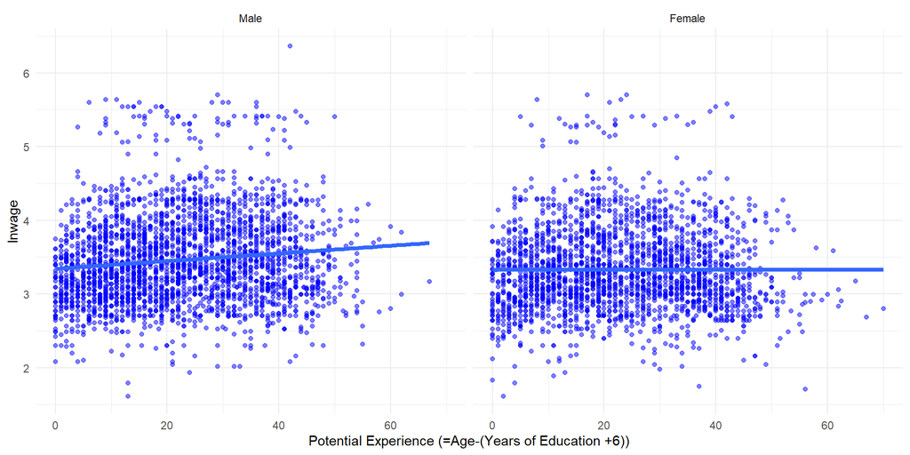

```r
wage_data <- read_dta(file.path(data_dir, "morg24_bothgen.dta"))

ggplot(wage_data, aes(x = exp, y = lnwage)) +
  geom_point(colour = "blue", alpha = 0.5) +
  geom_smooth(method = "lm", se = FALSE, linewidth = 1.5) +
  facet_wrap(~ as_factor(sex)) +
  labs(x = "Potential Experience (=Age-(Years of Education +6))") +
  theme_minimal()
```

If we overlay the fitted lines we get

- Stata
- R

```stata
* overlay fitted lines
twoway (lfit lnwage exp if sex==1, lc(blue)) (lfit lnwage exp if sex==2, lc(red) lwidth(*2)), xtitle("Potential Experience (=Age-(Years of Education +6))") legend(order(1 "Male" 2 "Female") r(2) ring(0) pos(5)) ylabel(2(1)6)
```

[figure not shown]

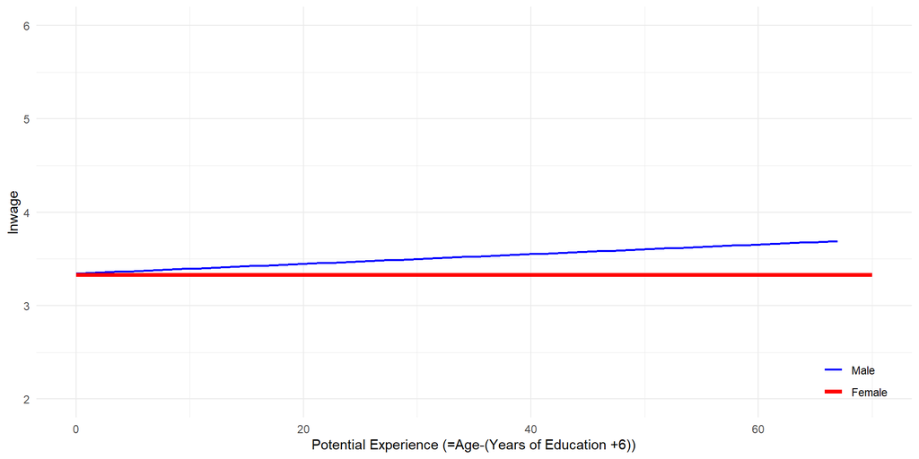

```r
wage_data$group <- factor(wage_data$sex, levels = c(1, 2),
                          labels = c("Male", "Female"))

ggplot(wage_data, aes(x = exp, y = lnwage, colour = group)) +
  geom_smooth(data = subset(wage_data, sex == 1),
              method = "lm", se = FALSE, linewidth = 0.75) +
  geom_smooth(data = subset(wage_data, sex == 2),
              method = "lm", se = FALSE, linewidth = 1.5) +
  scale_colour_manual(values = c(Male = "blue", Female = "red")) +
  scale_y_continuous(breaks = 2:6) +
  coord_cartesian(ylim = c(2, 6)) +
  labs(x = "Potential Experience (=Age-(Years of Education +6))",
       y = "lnwage", colour = NULL) +
  theme_minimal() +
  theme(legend.position = "inside",
        legend.position.inside = c(0.98, 0.02),
        legend.justification = c(1, 0))
```

## $F$-test

The $F$-test can be used to test differences in a model across groups.<sup>1</sup>

- For example, whether the Mincer equation (from Tutorial 1) differs by gender.

  $$\ln(wage_i) = \beta_0 + \beta_1 edu_i + \beta_2 exp_i + u_i$$
- We estimated this model for the male-only sample
- The quadratic term in $exp$ has been dropped for simplification
- The model has $k+1=3$ parameters
[^5]: We will look at the case of two groups, but the approach can be extended to multiple groups.

## Test:

We may wish to ask whether:

- the model for men (group = 1; e.g. “Male”)

  $$\ln(wage_i) = \textcolor{blue}{\beta_0} + \textcolor{blue}{\beta_1} edu_i + \textcolor{blue}{\beta_2} exp_i + u_i$$

is the same as,

- the model for women (group = 2; e.g. “Female”)?

  $$\ln(wage_i) = \textcolor{red}{\gamma_0} + \textcolor{red}{\gamma_1} edu_i + \textcolor{red}{\gamma_2} exp_i + u_i$$

## Null hypothesis

This question implies a null hypothesis:

$$H_0: \textcolor{blue}{\beta_0} = \textcolor{red}{\gamma_0},\;\textcolor{blue}{\beta_1} = \textcolor{red}{\gamma_1},\;\textcolor{blue}{\beta_2} = \textcolor{red}{\gamma_2}$$

against,

$$H_1: H_0\;\text{false}$$

## Chow test

The relevant $F$-statistic for this test is referred to as the Chow statistic:

$$F\text{-stat} = \frac{(SSR_P - (\textcolor{blue}{SSR_1} + \textcolor{red}{SSR_2}))/(k+1)}{(\textcolor{blue}{SSR_1} + \textcolor{red}{SSR_2})/(n-2(k+1))}$$

where,

- $SSR_P$ is the “pooled” ($P$) $SSR$ from a regression of the joint sample.
- $\textcolor{blue}{SSR_1}$ is the $SSR$ from a regression for just group 1.
- $\textcolor{red}{SSR_2}$ is the $SSR$ from a regression for just group 2.
  - together $\textcolor{blue}{SSR_1}$ and $\textcolor{red}{SSR_2}$ represent the unrestricted model.
- $n-2(k+1)$ is the **combined** degrees of freedom from group 1 and 2.
  - $k+1$ parameters are estimated in each group.

## Distribution

The $F$-stat is (unsurprisingly) $F$-distributed,

$$F\text{-stat} \underset{H_0}{\sim} F_{k+1,n-2(k+1)}$$

## Approach 2

This test has an equivalent form using interactions. Let,

$$d_i= \mathbf{1}\{\text{`Group 2'}\}$$

For example,

$$d_i= \mathbf{1}\{\text{`Female'}\}$$

## Interactions

We can write the unrestricted model as,

$$\ln(wage_i) = \beta_0 + \beta_1 edu_i+\beta_2 exp_i +\beta_3 d_i + \beta_4 edu_i\times d_i + \beta_5 exp_i\times d_i +u_i$$

We now have 6 parameters: $2\times (k+1)$ (for $k=2$)

As before, the dummy and dummy-interactions tell you about differences,

$$\beta_3 = E[\ln(wage_i)|\textcolor{red}{d_i=1},edu_i=0,exp_i=0]-E[\ln(wage_i)|\textcolor{blue}{d_i=0},edu_i=0,exp_i=0]$$

and

$$\beta_j = \frac{\partial E[\ln(wage_i)|\textcolor{red}{d_i=1},edu_i,exp_i]}{\partial x_{ij}}-\frac{\partial E[\ln(wage_i)|\textcolor{blue}{d_i=0},edu_i,exp_i]}{\partial x_{ij}} \qquad j=4,5$$

## Test

Intuitively, the test for whether the model differs by group is given by,

$$H_0: \beta_3 = 0,\;\beta_4=0,\;\beta_5=0$$

where,

- **unrestricted** model is given by,

$$\ln(wage_i) = \beta_0 + \beta_1 edu_i+\beta_2 exp_i +\beta_3 d_i + \beta_4 edu_i\times d_i + \beta_5 exp_i\times d_i +u_i$$

- $df_{ur} = n-6$
- **restricted** model is given by,

$$\ln(wage_i) = \beta_0 + \beta_1 edu_i + \beta_2 exp_i +v_i$$

- $df_{r} = n-3$

## $F$-stat

The $F$-stat is given by,

$$F\text{-stat} = \frac{(SSR_{r}-SSR_{ur})/3}{SSR_{ur}/(n-6)}$$

Compare this to the first approach:

$$F\text{-stat} = \frac{(SSR_P - (\textcolor{blue}{SSR_1} + \textcolor{red}{SSR_2}))/3}{(\textcolor{blue}{SSR_1} + \textcolor{red}{SSR_2})/(n-6)}$$

## Equivalence

These two test-statics are equivalent because,

1. $SSR_P=SSR_r$
2. $\textcolor{blue}{SSR_1} +\textcolor{red}{SSR_2} = SSR_{ur}$

## Demonstration

Here are the SSR for each version:

- Stata
- R
- Model for group 1 (i.e. “male”)

```stata
qui reg lnwage edu exp if sex==1
dis e(rss)
```

```
715.90864
```

- Model for group 2 (i.e. “female”)

```stata
qui reg lnwage edu exp if sex==2
dis e(rss)
```

```
539.59768
```

- Unrestricted model (i.e. with interactions)

```stata
qui reg lnwage i.sex##c.edu i.sex##c.exp
dis e(rss)
```

```
1255.5063
```

- Restricted model (i.e. without interactions)

```stata
qui reg lnwage edu exp
dis e(rss)
```

```
1307.1667
```

- Model for group 1 (i.e. “male”)

```r
model_m <- lm(lnwage ~ edu + exp, data = wage_data, subset = sex == 1)
deviance(model_m)
```

```
[1] 715.9086
```

- Model for group 2 (i.e. “female”)

```r
model_f <- lm(lnwage ~ edu + exp, data = wage_data, subset = sex == 2)
deviance(model_f)
```

```
[1] 539.5977
```

- Unrestricted model (i.e. with interactions)

```r
model_ur <- lm(lnwage ~ sex * edu + sex * exp, data = wage_data)
deviance(model_ur)
```

```
[1] 1255.506
```

- Restricted model (i.e. without interactions)

```r
model_r <- lm(lnwage ~ edu + exp, data = wage_data)
deviance(model_r)
```

```
[1] 1307.167
```

Here is how you would programme the test

- Stata
- R
- Estimate interacted model

```stata
qui reg lnwage i.sex##c.edu i.sex##c.exp
test 2.sex 2.sex#c.edu 2.sex#c.exp
```

```
 ( 1)  2.sex = 0
 ( 2)  2.sex#c.edu = 0
 ( 3)  2.sex#c.exp = 0

       F(  3,  4994) =   68.50
            Prob > F =    0.0000
```

The notation `2.sex` is how Stata names the coefficient on level `2` of the factor variable `sex`, and `2.sex#c.edu` is the interaction with `c.edu` (a `c`ontinuous variable).

- Estimate interacted model

```r
model_ur <- lm(lnwage ~ sex * edu + sex * exp, data = wage_data)
linearHypothesis(model_ur, c("sex2 = 0", "sex2:edu = 0", "sex2:exp = 0"))
```

```
Linear hypothesis test:
sex2 = 0
sex2:edu = 0
sex2:exp = 0

Model 1: restricted model
Model 2: lnwage ~ sex * edu + sex * exp

  Res.Df    RSS Df Sum of Sq      F    Pr(>F)
1   4997 1307.2
2   4994 1255.5  3     51.66 68.496 < 2.2e-16 ***
---
Signif. codes:  0 '***' 0.001 '**' 0.01 '*' 0.05 '.' 0.1 ' ' 1
```

The notation `sex2` is how R names the coefficient on level `2` of the factor `sex`, and `sex2:edu` its interaction with `edu` (a continuous variable).

# References

## Bibliography

Kleven, Henrik, Camille Landais, Johanna Posch, Andreas Steinhauer, and Josef Zweimüller. 2019. “Child Penalties Across Countries: Evidence and Explanations.” In *Aea Papers and Proceedings*, 109:122–26. American Economic Association 2014 Broadway, Suite 305, Nashville, TN 37203.

Wooldridge, Jeffrey M. 2025. “Introductory Econometrics: A Modern Approach.”